# Análisis descriptivo del dataset

Martín Ramírez Espinosa y Sergio Alejandro González Osorio

13 September 2025

## 1 Objetivo y descripción del documento

Este documento presenta un análisis descriptivo completo del dataset provisto. Se calculan y explican medidas de:

- Tendencia central (media, mediana, etc.) y promedios alternativos (geométrica, armónica, cuadrática).
- Dispersión (desviación media y mediana, varianza, desviación estándar, IQR).
- Forma (asimetría y curtosis).
- Comparaciones gráficas entre grupos para variables categóricas (género, fumador, bebedor).
- Relaciones entre variables numéricas mediante diagramas de dispersión con recta de regresión.

## 2 Carga y preparación de datos

```r
csv_path <- "dataset.csv"

data <- read.csv(csv_path, header = TRUE, stringsAsFactors = FALSE)

# Convertir variables cualitativas nominales a factores
data$genero <- as.factor(data$genero) # Género (M/F)
data$fumador <- as.factor(data$fumador) # ¿Fumador? (Si/No)
data$bebedor <- as.factor(data$bebedor) # ¿Bebedor? (Si/No)

# Asegurar que variables numéricas estén como numéricas
num_vars <- c("peso", "edad", "estatura", "calculo_diferencial", "calculo_integral", "dinero_dia")
for (v in num_vars) {
    data[[v]] <- suppressWarnings(as.numeric(data[[v]]))
}

# Variables categóricas a utilizar
cat_vars <- c("genero", "fumador", "bebedor")

# Vista rápida de la estructura y primeras filas
str(data)
```

```
## 'data.frame':    22 obs. of  9 variables:
##  $ peso               : num  92 53.8 49 83 67 54 67 57 60 65 ...
##  $ edad               : num  29 22 21 20 20 23 20 19 18 20 ...
##  $ estatura           : num  186 172 160 180 170 155 160 173 169 182 ...
##  $ genero             : Factor w/ 2 levels "F","M": 2 2 1 2 2 1 2 2 2 2 ...
##  $ calculo_diferencial: num  4.4 5 4.1 4 3.6 3.5 4.2 3.8 4 4 ...
##  $ calculo_integral   : num  3.6 4.1 4 3.8 4.5 3.8 4.3 4.8 3.4 4.2 ...
##  $ fumador            : Factor w/ 1 level "No": 1 1 1 1 1 1 1 1 1 1 ...
##  $ bebedor            : Factor w/ 2 levels "No","Si": 1 2 1 1 2 1 1 1 2 2 ...
##  $ dinero_dia         : num  20000 15000 5000 20000 25000 15000 10000 25000 20000 10000 ...
```

```r
head(data)
```

|  | peso | edad | estatura | genero | calculo_diferencial | calculo_integral | fumador | bebedor | dinero_dia |
| --- | --- | --- | --- | --- | --- | --- | --- | --- | --- |
| 1 | 92.0 | 29 | 186 | M | 4.4 | 3.6 | No | No | 20000 |
| 2 | 53.8 | 22 | 172 | M | 5.0 | 4.1 | No | Si | 15000 |
| 3 | 49.0 | 21 | 160 | F | 4.1 | 4.0 | No | No | 5000 |
| 4 | 83.0 | 20 | 180 | M | 4.0 | 3.8 | No | No | 20000 |
| 5 | 67.0 | 20 | 170 | M | 3.6 | 4.5 | No | Si | 25000 |
| 6 | 54.0 | 23 | 155 | F | 3.5 | 3.8 | No | No | 15000 |

## 3 Funciones auxiliares y definiciones estadísticas

A continuación, definimos funciones reutilizables para calcular promedios clásicos, medidas de dispersión, asimetría y curtosis, así como utilitarios para graficación.

```r
# Promedios para un vector numérico x_i (con resguardos para ceros/negativos)
get_means <- function(x_i) {
    # Subconjunto positivo para geométrica
    x_pos <- x_i[x_i > 0]
    # Subconjunto sin ceros para armónica
    x_zero_free <- x_i[x_i != 0]

    arithmetic_mean <- mean(x_i)
    geometric_mean <- (prod(x_pos))^(1 / length(x_pos))
    harmonic_mean <- length(x_zero_free) / sum(1 / x_zero_free)
    quadratic_mean <- sqrt(mean(x_i^2))

    list(
        arithmetic = arithmetic_mean,
        geometric  = geometric_mean,
        harmonic   = harmonic_mean,
        quadratic  = quadratic_mean
    )
}

# Medidas de dispersión para un vector numérico x_i
get_deviations <- function(x_i) {
    mean_deviation <- mean(abs(x_i - mean(x_i)))
    median_deviation <- median(abs(x_i - median(x_i)))
    variance <- var(x_i)
    std_deviation <- sd(x_i)

    list(
        mean_deviation   = mean_deviation,
        median_deviation = median_deviation,
        variance         = variance,
        std_deviation    = std_deviation
    )
}

# Asimetría muestral
get_skewness <- function(x_i) {
    return((1.0 / length(x_i)) * sum(((x_i - mean(x_i))^3)) / (sd(x_i)^3))
}

# Curtosis muestral
get_kurtosis <- function(x_i) {
    return((1.0 / length(x_i)) * sum(((x_i - mean(x_i))^4)) / (sd(x_i)^4))
}

# Resumen numérico con múltiples métricas para una variable
summarize_numeric <- function(x_i) {
    x_i <- x_i[!is.na(x_i)]
    means <- get_means(x_i)
    devs <- get_deviations(x_i)

    c(
        n               = length(x_i),
        min             = min(x_i),
        q1              = as.numeric(quantile(x_i, 0.25, names = FALSE)),
        median          = median(x_i),
        q3              = as.numeric(quantile(x_i, 0.75, names = FALSE)),
        max             = max(x_i),
        mean_arithmetic = means$arithmetic,
        mean_geometric  = means$geometric,
        mean_harmonic   = means$harmonic,
        mean_quadratic  = means$quadratic,
        sd              = devs$std_deviation,
        var             = devs$variance,
        iqr             = IQR(x_i),
        skewness        = get_skewness(x_i),
        kurtosis        = get_kurtosis(x_i)
    )
}

# Paleta de colores por niveles para variables categóricas
get_group_colors <- function(levels_vec, gvar) {
    if (gvar == "genero") {
        cmap <- c("F" = "#FFB6C1", "M" = "#87CEEB")
    } else if (gvar == "bebedor") {
        cmap <- c("No" = "#D3D3D3", "Si" = "#F0E68C")
    } else if (gvar == "fumador") {
        cmap <- c("No" = "#D3D3D3", "Si" = "#A9A9A9")
    } else {
        cmap <- setNames(rep("#CCCCCC", length(levels_vec)), levels_vec)
    }
    cols <- unname(ifelse(levels_vec %in% names(cmap), cmap[levels_vec], "#CCCCCC"))
    cols
}

# Paleta característica por variable numérica (para sección 4.1)
get_numeric_var_colors <- function(v) {
    # Colores llamativos y legibles
    switch(v,
        "dinero_dia" = list(fill = "#2ECC71", line = "#1E8449", outlier = "#145A32"), # verde billete
        "peso" = list(fill = "#4E79A7", line = "#2F4B7C", outlier = "#1B2A41"), # azul
        "edad" = list(fill = "#F28E2B", line = "#B05A00", outlier = "#7A3D00"), # naranja
        "estatura" = list(fill = "#B07AA1", line = "#7A4F78", outlier = "#5A3A5E"), # morado
        "calculo_diferencial" = list(fill = "#76B7B2", line = "#4E8F8B", outlier = "#3A6A67"), # verde azulado
        "calculo_integral" = list(fill = "#E15759", line = "#A23537", outlier = "#7A2527"), # rojo coral
        list(fill = "#74ADD1", line = "#D73027", outlier = "#555555") # por defecto
    )
}

# Utilidad para trazar dispersión + recta de regresión (ggplot2)
plot_with_lm <- function(x, y, xlab, ylab, main) {
    df <- data.frame(x = x, y = y)
    df <- df[is.finite(df$x) & is.finite(df$y), , drop = FALSE]
    ggplot2::ggplot(df, ggplot2::aes(x = x, y = y)) +
        ggplot2::geom_point(ggplot2::aes(color = "Datos"), alpha = 0.85, size = 2.5) +
        ggplot2::geom_smooth(ggplot2::aes(color = "Ajuste lineal"), method = "lm", formula = y ~ x, se = TRUE, linewidth = 1.1) +
        ggplot2::scale_color_manual(values = c("Datos" = "#4575b4", "Ajuste lineal" = "#d73027"), name = NULL) +
        ggplot2::labs(title = main, x = xlab, y = ylab) +
        ggplot2::theme_minimal(base_size = 13)
}

# Graficador estético de histograma + densidad (ggplot2)
hist_density_plot <- function(x, v) {
    x <- x[!is.na(x)]
    bins <- tryCatch(nclass.FD(x), error = function(e) 10)
    bins <- max(5, ifelse(is.finite(bins), bins, 10))
    df <- data.frame(x = x)
    cols <- get_numeric_var_colors(v)
    ggplot2::ggplot(df, ggplot2::aes(x)) +
        ggplot2::geom_histogram(ggplot2::aes(y = ggplot2::after_stat(density), fill = "Histograma"),
            bins = bins, color = "white", alpha = 0.85
        ) +
        ggplot2::geom_density(ggplot2::aes(color = "Densidad"), linewidth = 1.1, na.rm = TRUE) +
        ggplot2::scale_fill_manual(values = c("Histograma" = cols$fill), name = NULL) +
        ggplot2::scale_color_manual(values = c("Densidad" = cols$line), name = NULL) +
        ggplot2::geom_rug(alpha = 0.25) +
        ggplot2::labs(title = paste("Distribución de", v), x = v, y = "Densidad") +
        ggplot2::theme_minimal(base_size = 13) +
        ggplot2::theme(
            plot.title = ggplot2::element_text(face = "bold"),
            panel.grid.minor = ggplot2::element_blank()
        )
}

# Boxplot univariado
boxplot_single <- function(x, v) {
    x <- x[!is.na(x)]
    df <- data.frame(x = x)
    cols <- get_numeric_var_colors(v)
    ggplot2::ggplot(df, ggplot2::aes(x = "", y = x)) +
        ggplot2::geom_boxplot(fill = cols$fill, outlier.colour = cols$outlier, width = 0.3) +
        ggplot2::coord_flip() +
        ggplot2::labs(title = paste("Boxplot de", v), x = NULL, y = v) +
        ggplot2::theme_minimal(base_size = 13) +
        ggplot2::theme(plot.title = ggplot2::element_text(face = "bold"))
}

# Boxplot por grupos
boxplot_grouped <- function(values, groups, nv, gvar) {
    df <- data.frame(value = values, group = droplevels(as.factor(groups)))
    df <- df[!is.na(df$value) & !is.na(df$group), , drop = FALSE]
    cols <- get_group_colors(levels(df$group), gvar)
    names(cols) <- levels(df$group)
    ggplot2::ggplot(df, ggplot2::aes(x = group, y = value, fill = group)) +
        ggplot2::geom_boxplot(outlier.colour = "#555555", width = 0.6) +
        ggplot2::scale_fill_manual(values = cols) +
        ggplot2::coord_flip() +
        ggplot2::labs(title = paste("Boxplot de", nv, "por", gvar), x = gvar, y = nv, fill = gvar) +
        ggplot2::theme_minimal(base_size = 13) +
        ggplot2::theme(plot.title = ggplot2::element_text(face = "bold"))
}

# Barras para variable categórica con etiquetas y leyenda
cat_bar_plot <- function(vec, v) {
    fac <- droplevels(as.factor(vec))
    df <- as.data.frame(table(fac), stringsAsFactors = FALSE)
    names(df) <- c("group", "freq")
    df$group <- factor(df$group, levels = levels(fac))
    cols <- get_group_colors(levels(fac), v)
    names(cols) <- levels(fac)
    ggplot2::ggplot(df, ggplot2::aes(x = group, y = freq, fill = group)) +
        ggplot2::geom_col(width = 0.65, color = "white") +
        ggplot2::geom_text(ggplot2::aes(label = freq), vjust = -0.25, size = 3.6) +
        ggplot2::scale_fill_manual(values = cols, name = v) +
        ggplot2::labs(title = paste("Frecuencias de", v), x = v, y = "Frecuencia") +
        ggplot2::expand_limits(y = max(df$freq) * 1.15) +
        ggplot2::theme_minimal(base_size = 13)
}

# Pie/Donut con porcentajes claros y leyenda
cat_pie_plot <- function(vec, v) {
    fac <- droplevels(as.factor(vec))
    df <- as.data.frame(table(fac), stringsAsFactors = FALSE)
    names(df) <- c("group", "freq")
    df$group <- factor(df$group, levels = levels(fac))
    df$prop <- df$freq / sum(df$freq)
    df$label <- paste0(round(100 * df$prop), "%")
    cols <- get_group_colors(levels(fac), v)
    names(cols) <- levels(fac)
    ggplot2::ggplot(df, ggplot2::aes(x = "", y = prop, fill = group)) +
        ggplot2::geom_col(width = 1, color = "white") +
        ggplot2::coord_polar(theta = "y") +
        ggplot2::geom_text(ggplot2::aes(label = label), position = ggplot2::position_stack(vjust = 0.5), size = 3.7, color = "black") +
        ggplot2::scale_fill_manual(values = cols, name = v) +
        ggplot2::labs(title = paste("Proporciones de", v), x = NULL, y = NULL, fill = v) +
        ggplot2::theme_minimal(base_size = 13) +
        ggplot2::theme(
            axis.title = ggplot2::element_blank(),
            axis.text = ggplot2::element_blank(),
            axis.ticks = ggplot2::element_blank(),
            panel.grid = ggplot2::element_blank()
        )
}
```

## 4 Análisis descriptivo de variables numéricas

En esta sección presentamos estadísticas descriptivas para las variables numéricas y sus gráficas básicas (histograma con densidad y boxplot).

```r
# Tabla de resumen por variable numérica
numeric_summary <- lapply(num_vars, function(v) {
    stats <- summarize_numeric(data[[v]])
    df <- data.frame(variable = v, t(stats), row.names = NULL, check.names = FALSE)
    # Redondeo para presentación (excluir 'n' para que quede entero)
    num_cols <- setdiff(names(df), c("variable", "n"))
    df[num_cols] <- lapply(df[num_cols], function(x) if (is.numeric(x)) round(x, 3) else x)
    df
})

numeric_summary <- do.call(rbind, numeric_summary)
# Asegurar 'n' como entero
suppressWarnings(numeric_summary$n <- as.integer(numeric_summary$n))

# 1) Medidas de posición
posicion <- numeric_summary[, c("variable", "n", "min", "q1", "median", "q3", "max")]
colnames(posicion) <- c("Variable", "n", "Mín", "Q1", "Mediana", "Q3", "Máx")
knitr::kable(posicion, caption = "Medidas de posición por variable", align = c("l", rep("r", 6)))
```

Medidas de posición por variable

| Variable | n | Mín | Q1 | Mediana | Q3 | Máx |
| --- | --- | --- | --- | --- | --- | --- |
| peso | 22 | 49.0 | 56.25 | 67.0 | 75.000 | 92.0 |
| edad | 22 | 18.0 | 20.00 | 21.5 | 24.500 | 29.0 |
| estatura | 22 | 155.0 | 169.25 | 173.5 | 179.000 | 186.0 |
| calculo_diferencial | 22 | 3.4 | 3.60 | 3.9 | 4.175 | 5.0 |
| calculo_integral | 22 | 3.0 | 3.50 | 3.8 | 4.175 | 4.8 |
| dinero_dia | 22 | 500.0 | 10000.00 | 15000.0 | 20000.000 | 50000.0 |

```r
# 2) Promedios clásicos
promedios <- numeric_summary[, c("variable", "mean_arithmetic", "mean_geometric", "mean_harmonic", "mean_quadratic")]
colnames(promedios) <- c("Variable", "Media (aritm.)", "Media (geom.)", "Media (arm.)", "Media (cuad.)")
knitr::kable(promedios, caption = "Promedios clásicos por variable", align = c("l", rep("r", 4)))
```

Promedios clásicos por variable

| Variable | Media (aritm.) | Media (geom.) | Media (arm.) | Media (cuad.) |
| --- | --- | --- | --- | --- |
| peso | 68.127 | 66.994 | 65.894 | 69.273 |
| edad | 22.045 | 21.838 | 21.642 | 22.264 |
| estatura | 172.455 | 172.244 | 172.030 | 172.662 |
| calculo_diferencial | 3.927 | 3.904 | 3.881 | 3.952 |
| calculo_integral | 3.791 | 3.756 | 3.721 | 3.825 |
| dinero_dia | 18204.545 | 14093.473 | 6370.656 | 21637.772 |

```r
# 3) Dispersión y forma
disp_forma <- numeric_summary[, c("variable", "sd", "var", "iqr", "skewness", "kurtosis")]
colnames(disp_forma) <- c("Variable", "DE", "Var", "RI", "Asimetría", "Curtosis")
knitr::kable(disp_forma, caption = "Medidas de dispersión y forma por variable", align = c("l", rep("r", 5)))
```

Medidas de dispersión y forma por variable

| Variable | DE | Var | RI | Asimetría | Curtosis |
| --- | --- | --- | --- | --- | --- |
| peso | 12.844 | 1.649660e+02 | 18.750 | 0.332 | 1.876 |
| edad | 3.184 | 1.014100e+01 | 4.500 | 0.712 | 2.317 |
| estatura | 8.651 | 7.483100e+01 | 9.750 | -0.399 | 2.090 |
| calculo_diferencial | 0.456 | 2.080000e-01 | 0.575 | 0.946 | 3.176 |
| calculo_integral | 0.521 | 2.710000e-01 | 0.675 | -0.007 | 2.022 |
| dinero_dia | 11970.857 | 1.433014e+08 | 10000.000 | 1.435 | 4.870 |

### 4.1 Interpretación de las medidas numéricas

En esta sección se interpreta cada métrica anterior y se clasifica la forma de la distribución según la curtosis: platicúrtica (kurtosis < 2.5), mesocúrtica (≈ 3) o leptocúrtica (> 3). La asimetría se lee por el signo y la magnitud del coeficiente.

Lectura e interpretación de las medidas por variable

| Variable | n | Media | Mediana | DE | RI | Asimetría | Lectura asimetría | Curtosis | Lectura curtosis |
| --- | --- | --- | --- | --- | --- | --- | --- | --- | --- |
| peso | 22 | 68.127 | 67.0 | 12.844 | 18.750 | 0.332 | Aproximadamente simétrica | 1.876 | Platicúrtica (colas ligeras, más achatada) |
| edad | 22 | 22.045 | 21.5 | 3.184 | 4.500 | 0.712 | Sesgo positivo (cola a la derecha) | 2.317 | Platicúrtica (colas ligeras, más achatada) |
| estatura | 22 | 172.455 | 173.5 | 8.651 | 9.750 | -0.399 | Aproximadamente simétrica | 2.090 | Platicúrtica (colas ligeras, más achatada) |
| calculo_diferencial | 22 | 3.927 | 3.9 | 0.456 | 0.575 | 0.946 | Sesgo positivo (cola a la derecha) | 3.176 | Mesocúrtica (similar a la Normal) |
| calculo_integral | 22 | 3.791 | 3.8 | 0.521 | 0.675 | -0.007 | Aproximadamente simétrica | 2.022 | Platicúrtica (colas ligeras, más achatada) |
| dinero_dia | 22 | 18204.545 | 15000.0 | 11970.857 | 10000.000 | 1.435 | Sesgo positivo (cola a la derecha) | 4.870 | Leptocúrtica (colas pesadas, pico agudo) |

#### 4.1.1 Comentarios por variable (qué esperar en las gráficas)

La siguiente síntesis textual enlaza medidas con la lectura visual de histogramas y boxplots (presencia de sesgo, concentración/dispersion y atípicos por regla de Tukey).

##### 4.1.1.1 peso

- Tendencia central: media = 68.127, mediana = 67.000. Son cercanas (distribución no muy sesgada).
- Dispersión: DE = 12.844, RI = 18.750. Un RI más pequeño implica cajas compactas en el boxplot.
- Forma: asimetría = 0.332 [Aproximadamente simétrica]; curtosis = 1.876 [Platicúrtica (colas ligeras, más achatada)].
- Atípicos (regla 1.5·RI): 0; umbrales esperados [28.125, 103.125].
- Lectura visual esperada: el histograma+density debería reflejar simetría aproximada, y el boxplot puede mostrar pocos o ningún atípico.

##### 4.1.1.2 edad

- Tendencia central: media = 22.045, mediana = 21.500. Son cercanas (distribución no muy sesgada).
- Dispersión: DE = 3.184, RI = 4.500. Un RI más pequeño implica cajas compactas en el boxplot.
- Forma: asimetría = 0.712 [Sesgo positivo (cola a la derecha)]; curtosis = 2.317 [Platicúrtica (colas ligeras, más achatada)].
- Atípicos (regla 1.5·RI): 0; umbrales esperados [13.250, 31.250].
- Lectura visual esperada: el histograma+density debería reflejar cola a la derecha, y el boxplot puede mostrar pocos o ningún atípico.

##### 4.1.1.3 estatura

- Tendencia central: media = 172.455, mediana = 173.500. Son cercanas (distribución no muy sesgada).
- Dispersión: DE = 8.651, RI = 9.750. Un RI más pequeño implica cajas compactas en el boxplot.
- Forma: asimetría = -0.399 [Aproximadamente simétrica]; curtosis = 2.090 [Platicúrtica (colas ligeras, más achatada)].
- Atípicos (regla 1.5·RI): 0; umbrales esperados [154.625, 193.625].
- Lectura visual esperada: el histograma+density debería reflejar simetría aproximada, y el boxplot puede mostrar pocos o ningún atípico.

##### 4.1.1.4 calculo_diferencial

- Tendencia central: media = 3.927, mediana = 3.900. Son cercanas (distribución no muy sesgada).
- Dispersión: DE = 0.456, RI = 0.575. Un RI más pequeño implica cajas compactas en el boxplot.
- Forma: asimetría = 0.946 [Sesgo positivo (cola a la derecha)]; curtosis = 3.176 [Mesocúrtica (similar a la Normal)].
- Atípicos (regla 1.5·RI): 0; umbrales esperados [2.737, 5.038].
- Lectura visual esperada: el histograma+density debería reflejar cola a la derecha, y el boxplot puede mostrar pocos o ningún atípico.

##### 4.1.1.5 calculo_integral

- Tendencia central: media = 3.791, mediana = 3.800. Son cercanas (distribución no muy sesgada).
- Dispersión: DE = 0.521, RI = 0.675. Un RI más pequeño implica cajas compactas en el boxplot.
- Forma: asimetría = -0.007 [Aproximadamente simétrica]; curtosis = 2.022 [Platicúrtica (colas ligeras, más achatada)].
- Atípicos (regla 1.5·RI): 0; umbrales esperados [2.487, 5.188].
- Lectura visual esperada: el histograma+density debería reflejar simetría aproximada, y el boxplot puede mostrar pocos o ningún atípico.

##### 4.1.1.6 dinero_dia

- Tendencia central: media = 18204.545, mediana = 15000.000. Se alejan (posible sesgo o atípicos).
- Dispersión: DE = 11970.857, RI = 10000.000. Un RI más pequeño implica cajas compactas en el boxplot.
- Forma: asimetría = 1.435 [Sesgo positivo (cola a la derecha)]; curtosis = 4.870 [Leptocúrtica (colas pesadas, pico agudo)].
- Atípicos (regla 1.5·RI): 2; umbrales esperados [-5000.000, 35000.000].
- Lectura visual esperada: el histograma+density debería reflejar cola a la derecha, y el boxplot puede mostrar puntos atípicos.

### 4.2 Histogramas con densidad y Boxplots

Para cada variable numérica se muestra un histograma con la densidad estimada superpuesta y su boxplot correspondiente.

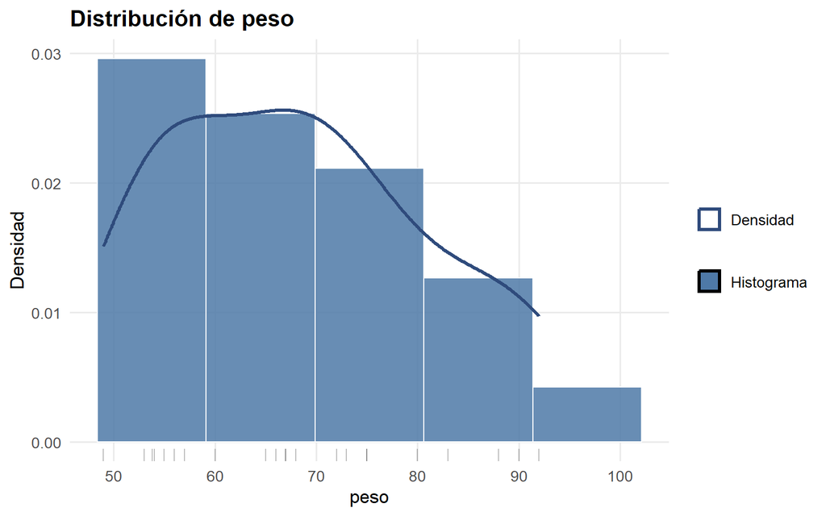

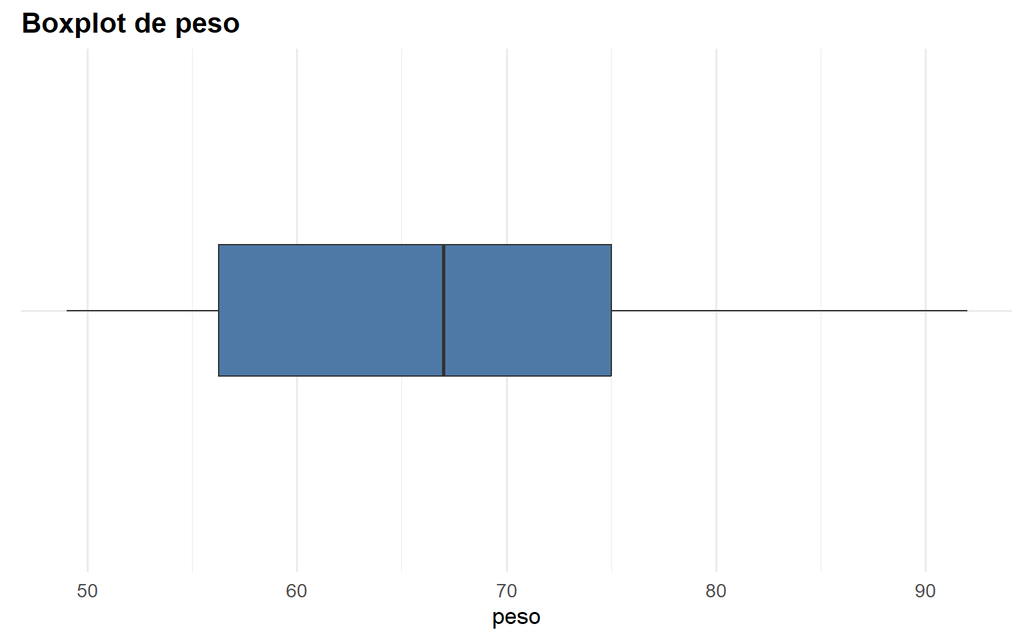

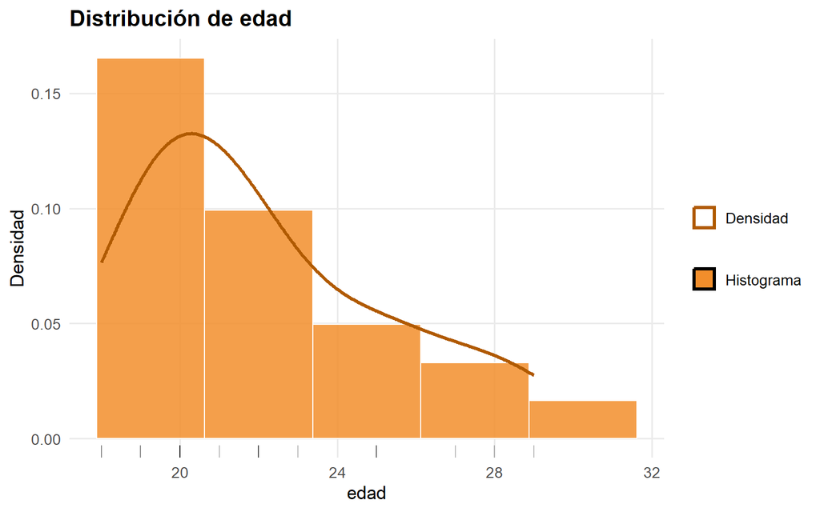

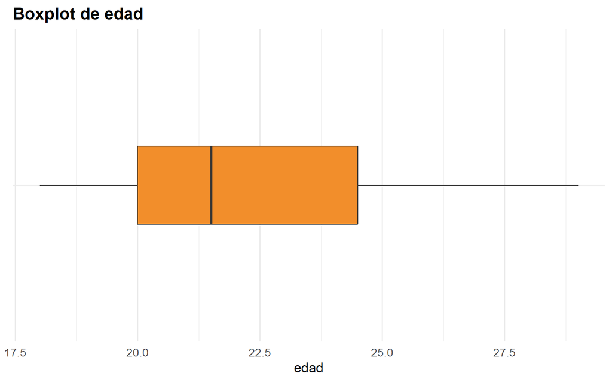

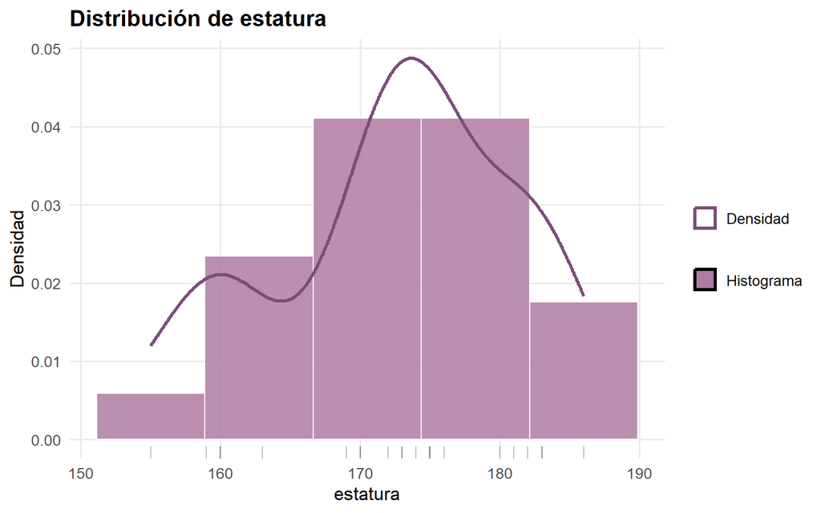

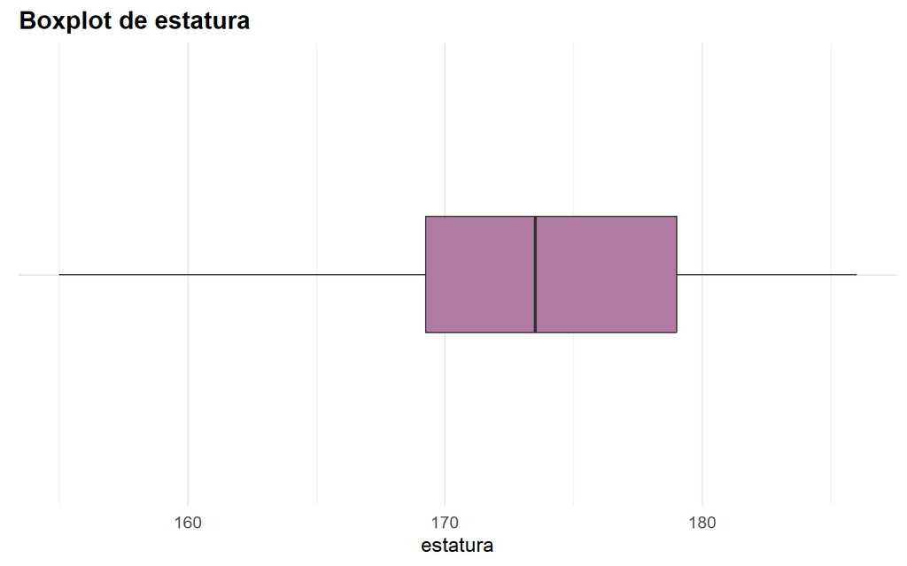

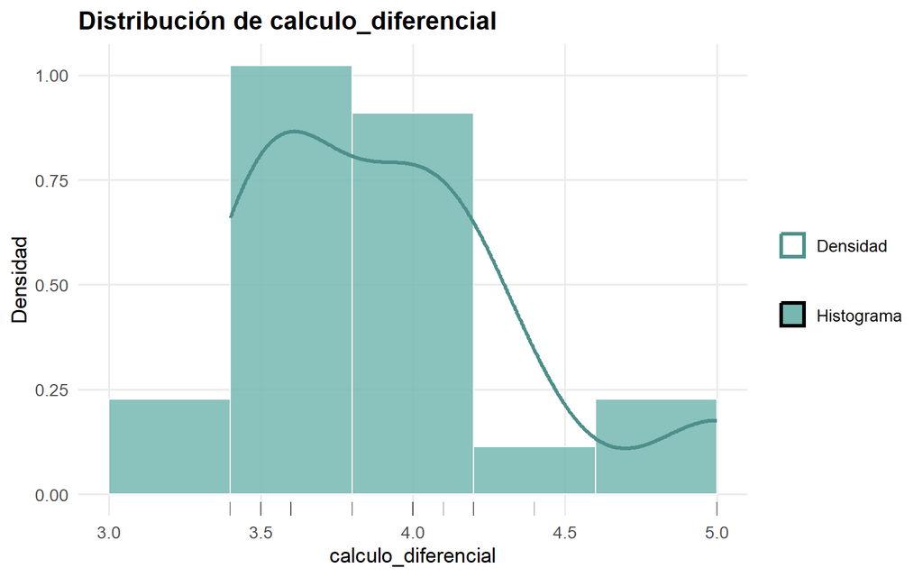

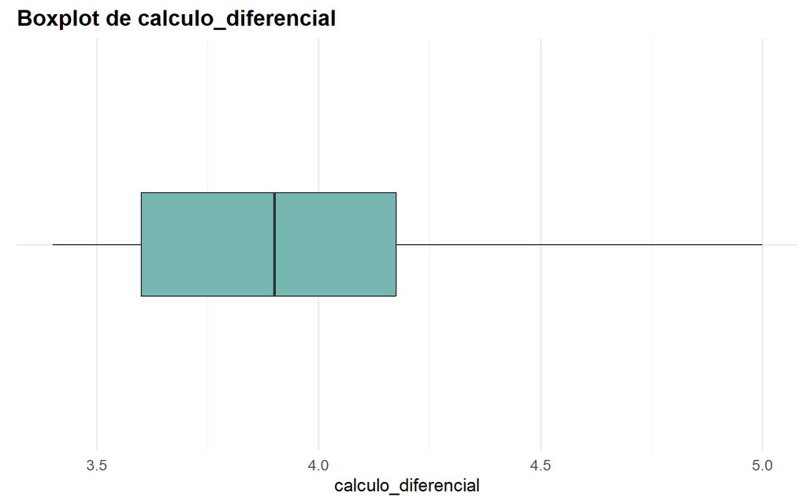

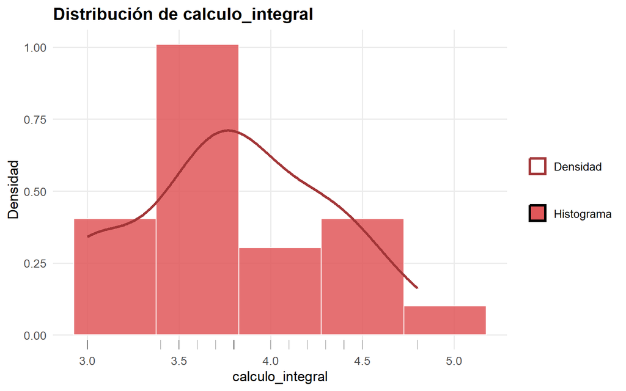

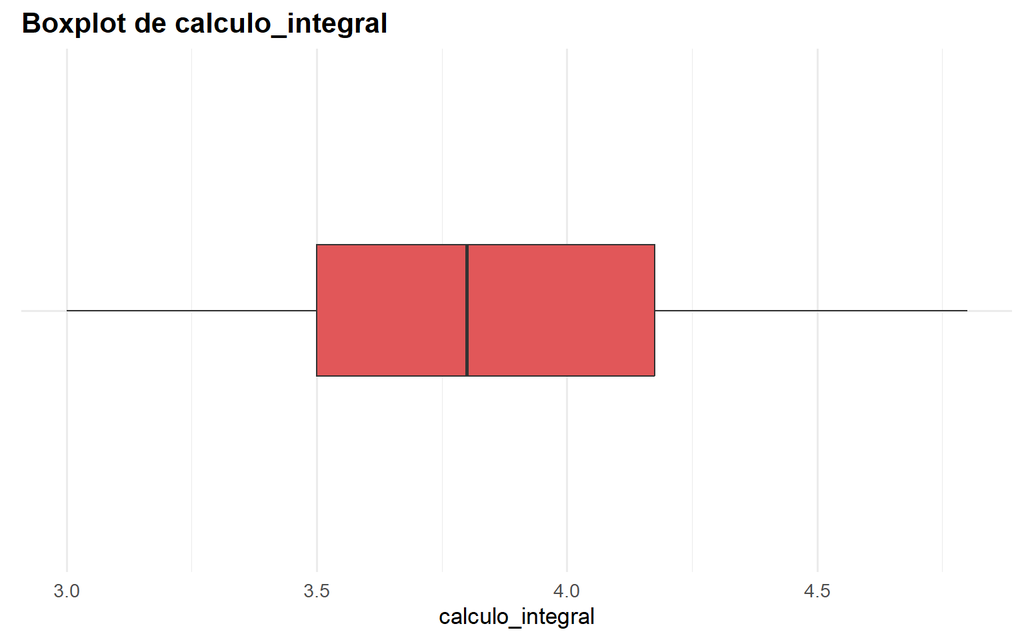

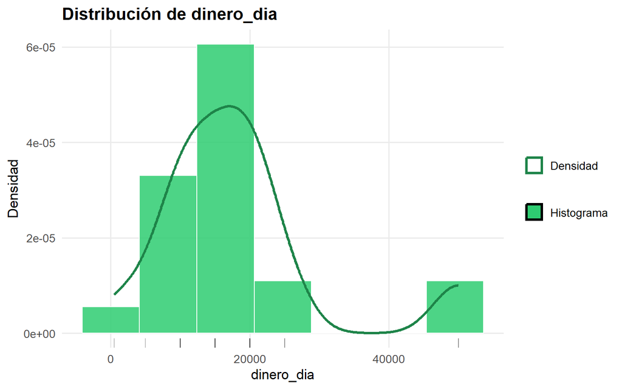

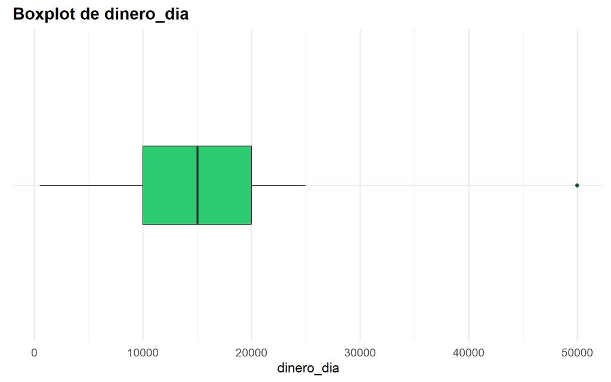

```r
for (v in num_vars) {
    x_i <- data[[v]]
    print(hist_density_plot(x_i, v))
    print(boxplot_single(x_i, v))
}
```

## 5 Variables categóricas: frecuencias y proporciones

Analizamos la distribución de cada variable categórica (`genero`, `fumador`, `bebedor`) mediante tablas de frecuencias y proporciones, además de gráficas de barras y de pastel.

```
##
##
## Table: Frecuencias de genero
##
## |genero | Frecuencia|
## |:------|----------:|
## |F      |          4|
## |M      |         18|
##
##
## Table: Proporciones de genero
##
## |genero | Proporción|
## |:------|----------:|
## |F      |      0.182|
## |M      |      0.818|
```

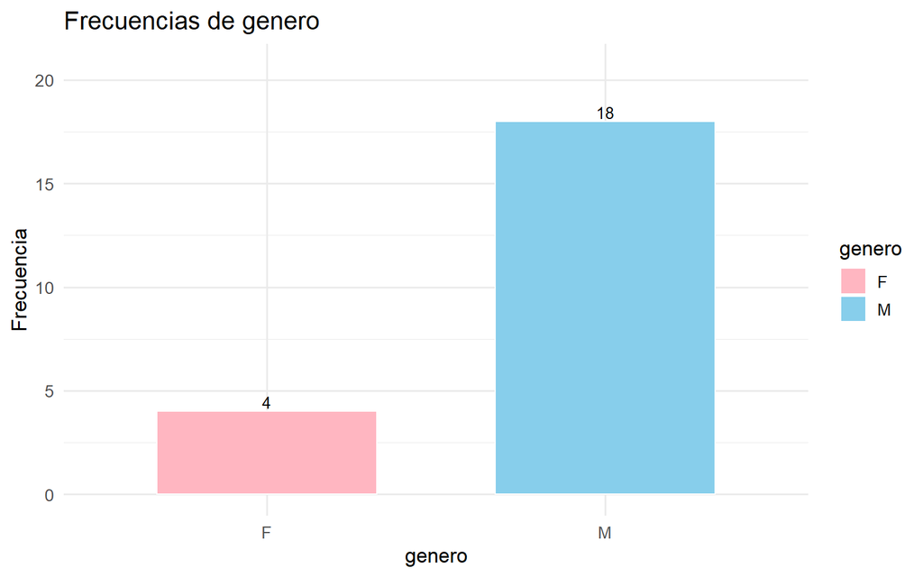

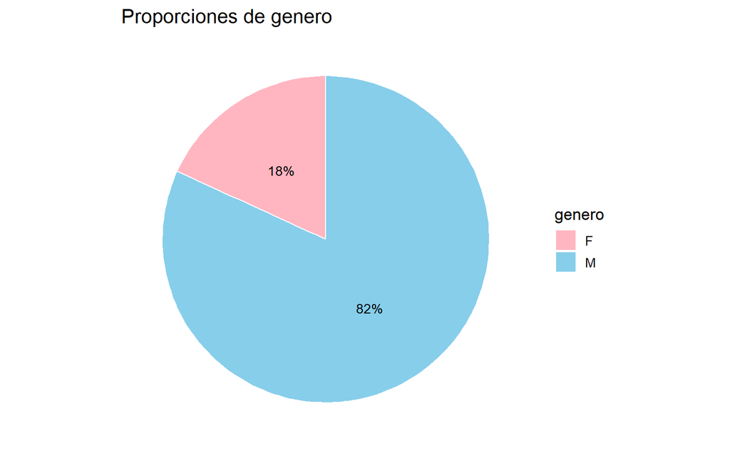

```
##
##
## Table: Frecuencias de fumador
##
## |fumador | Frecuencia|
## |:-------|----------:|
## |No      |         22|
##
##
## Table: Proporciones de fumador
##
## |fumador | Proporción|
## |:-------|----------:|
## |No      |          1|
```

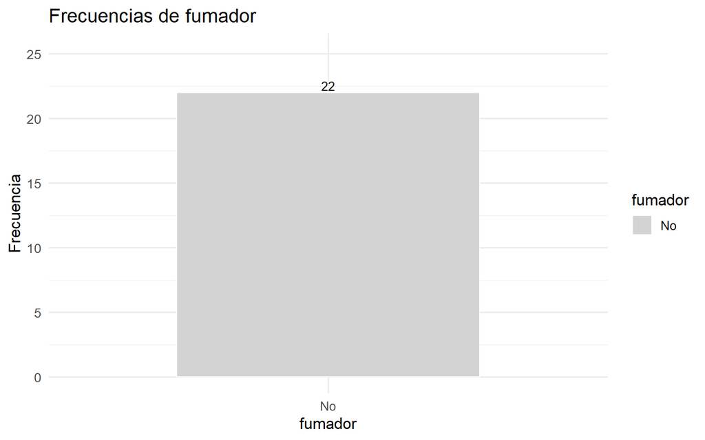

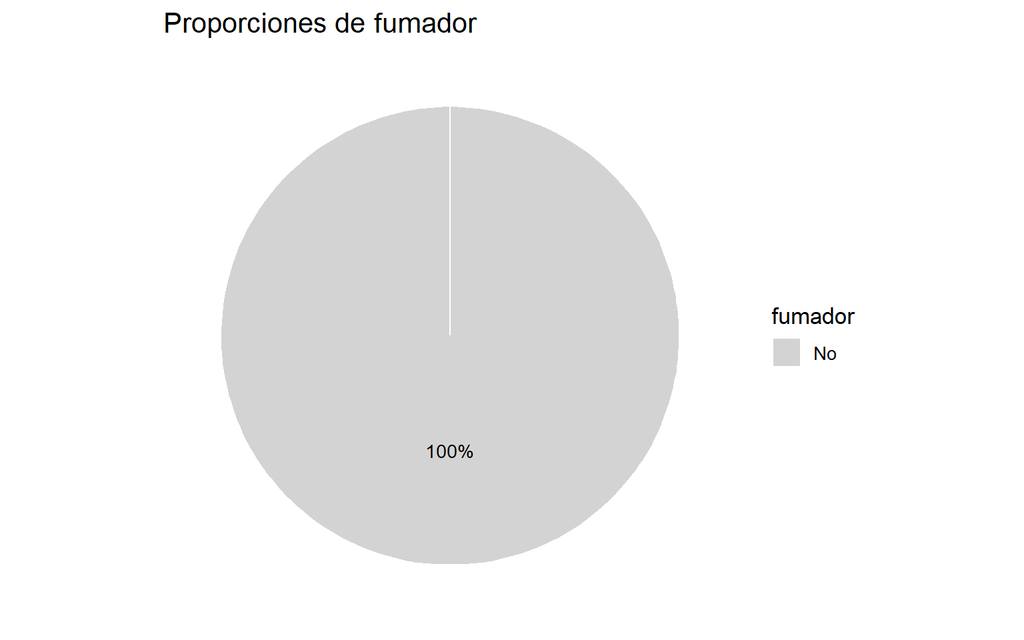

```
##
##
## Table: Frecuencias de bebedor
##
## |bebedor | Frecuencia|
## |:-------|----------:|
## |No      |         14|
## |Si      |          8|
##
##
## Table: Proporciones de bebedor
##
## |bebedor | Proporción|
## |:-------|----------:|
## |No      |      0.636|
## |Si      |      0.364|
```

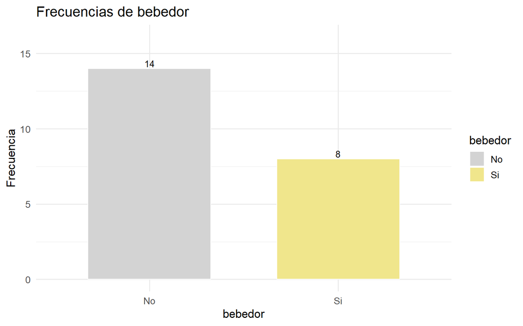

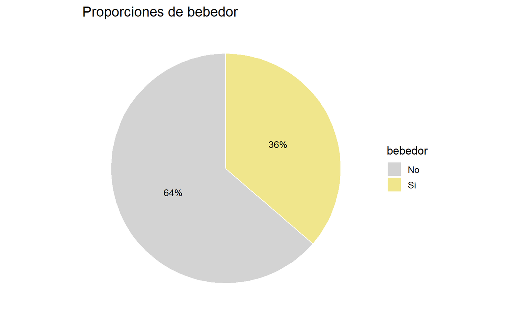

````
### Interpretación de variables categóricas

A continuación se resumen los niveles predominantes y el balance de cada variable categórica (si la distribución está muy concentrada en una categoría o más bien equilibrada).


```
##
##
## #### genero
## - Categoría más frecuente: M (81.8%).
## - Lectura de barras/pastel: Distribución desbalanceada (una categoría domina).
##
##
## #### fumador
## - Categoría más frecuente: No (100.0%).
## - Lectura de barras/pastel: Distribución desbalanceada (una categoría domina).
##
##
## #### bebedor
## - Categoría más frecuente: No (63.6%).
## - Lectura de barras/pastel: Distribución desbalanceada (una categoría domina).
```
````

```r
for (v in cat_vars) {
    tab <- table(data[[v]])
    prop <- prop.table(tab)

    # Mostrar tablas legibles
    print(knitr::kable(as.data.frame(tab),
        col.names = c(v, "Frecuencia"),
        caption = paste("Frecuencias de", v)
    ))
    print(knitr::kable(as.data.frame(round(prop, 3)),
        col.names = c(v, "Proporción"),
        caption = paste("Proporciones de", v)
    ))

    # Gráficas estéticas con ggplot2
    print(cat_bar_plot(data[[v]], v))
    print(cat_pie_plot(data[[v]], v))
}
```

## 6 Comparaciones entre grupos (boxplots)

Para cada variable numérica, comparamos su distribución entre los niveles de cada variable categórica usando boxplots.

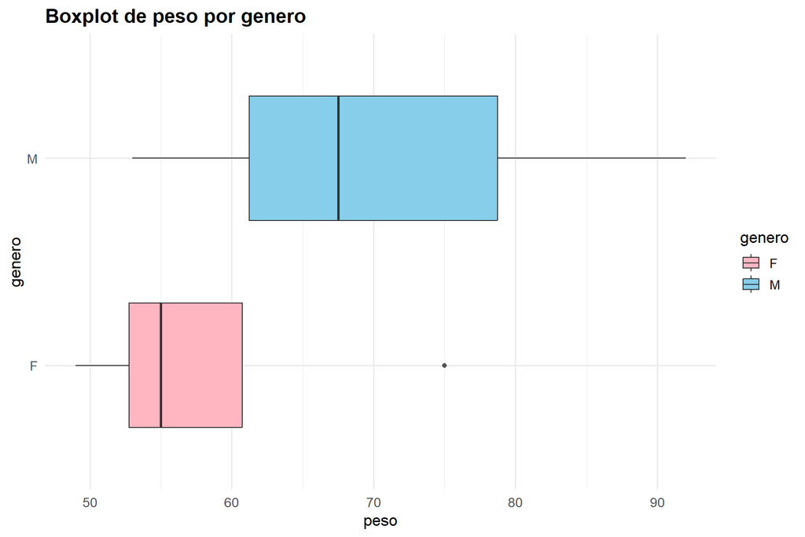

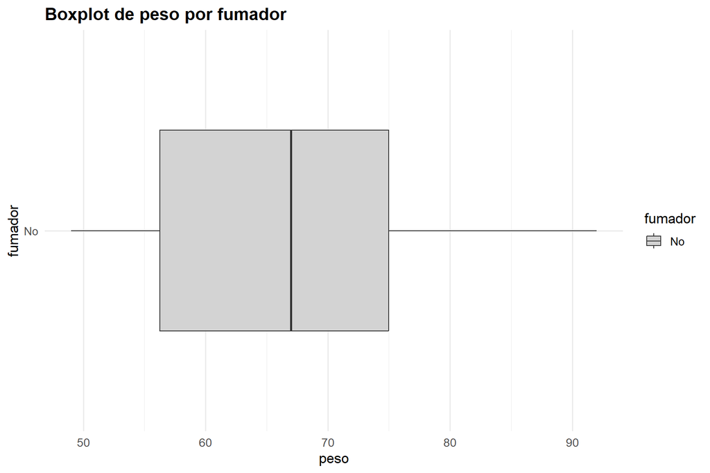

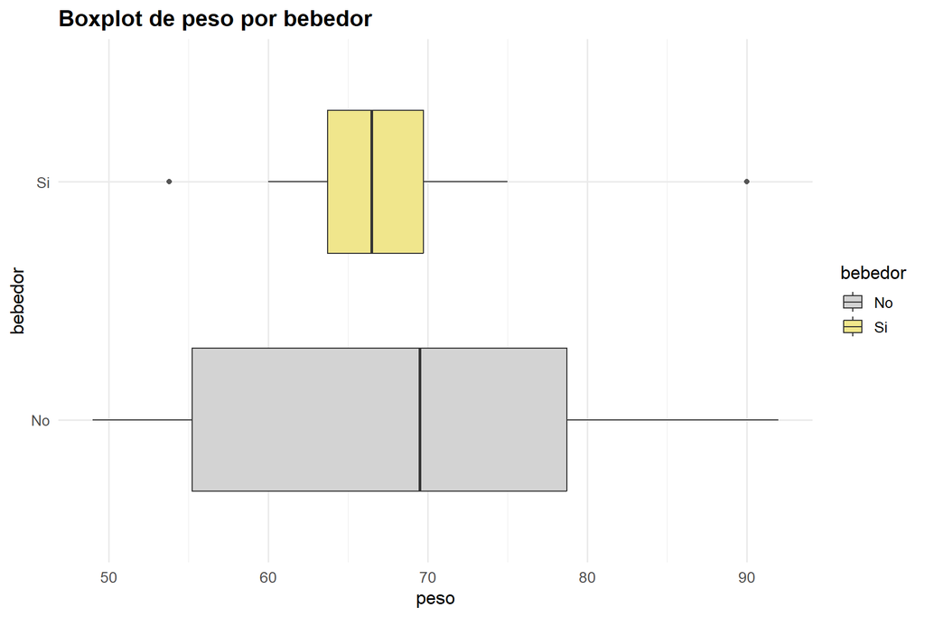

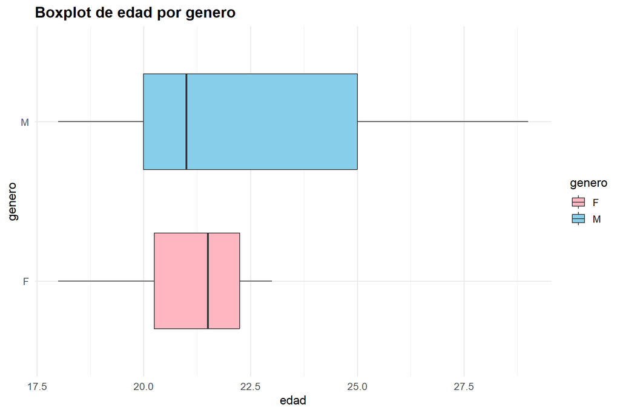

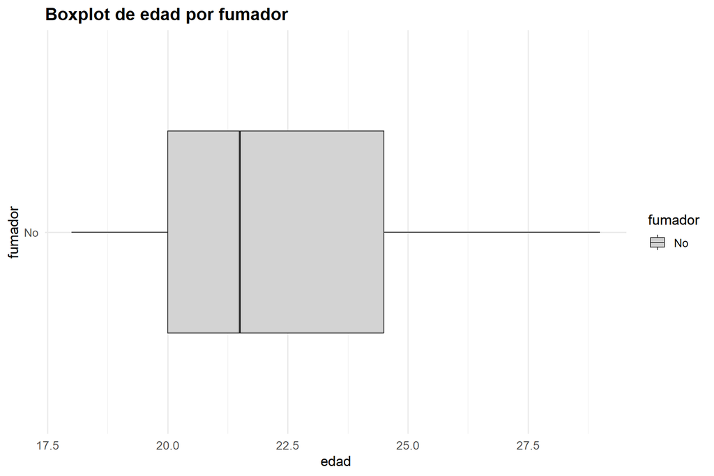

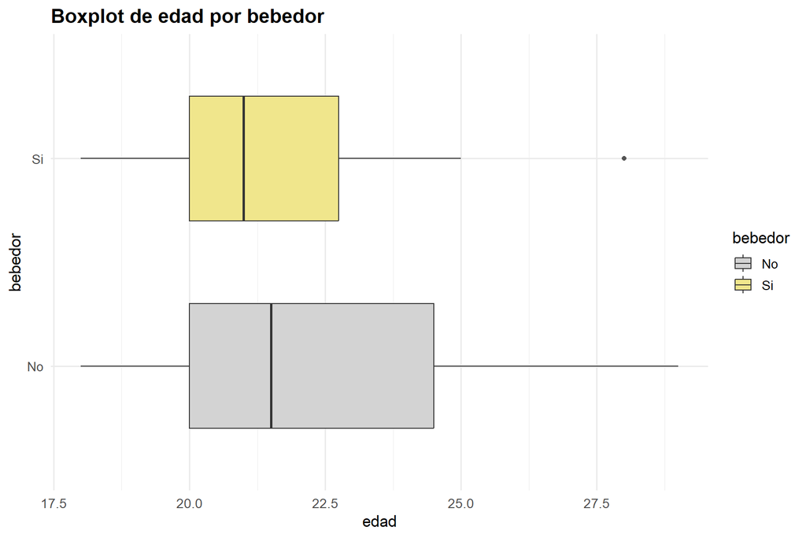

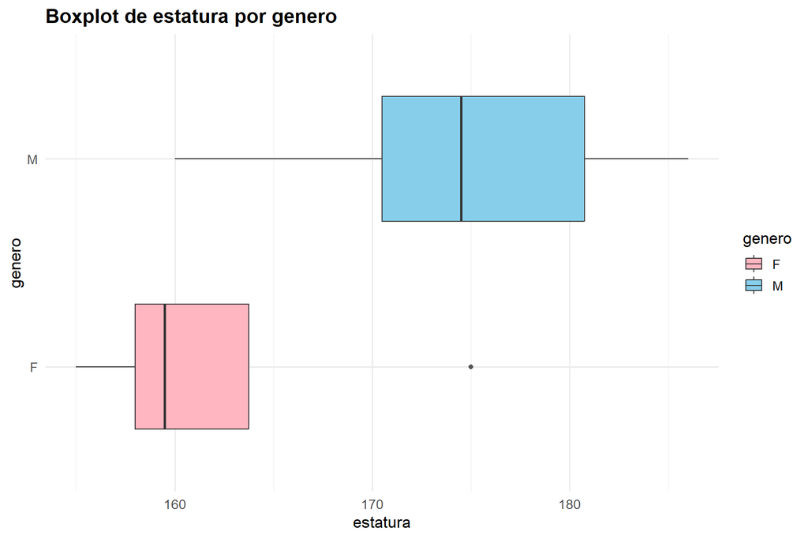

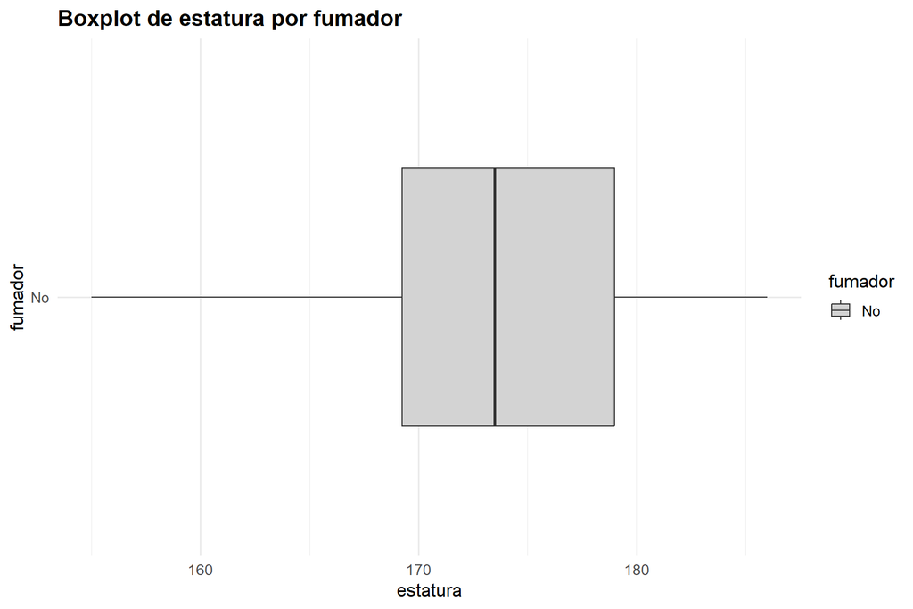

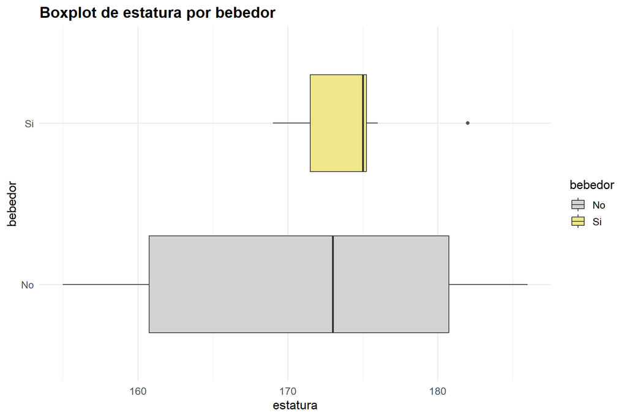

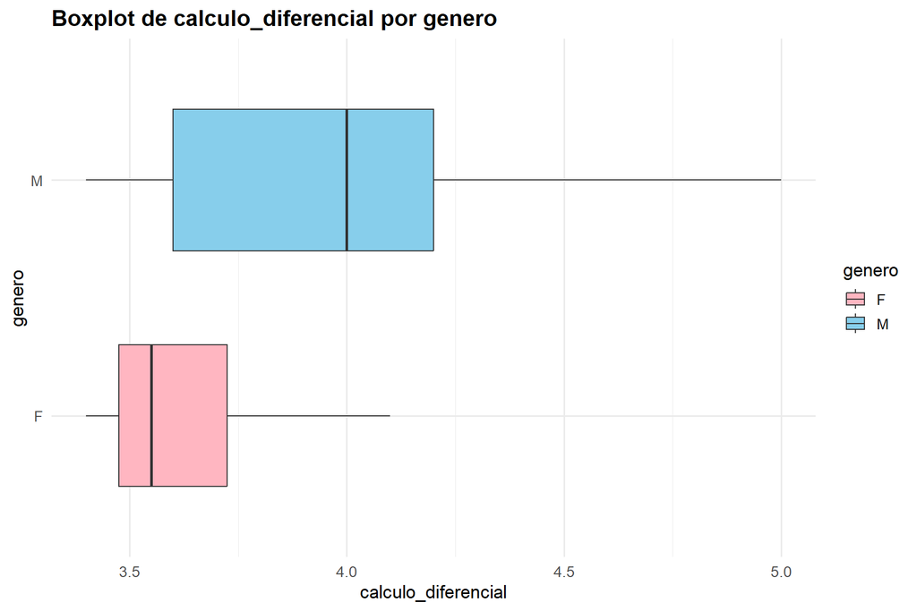

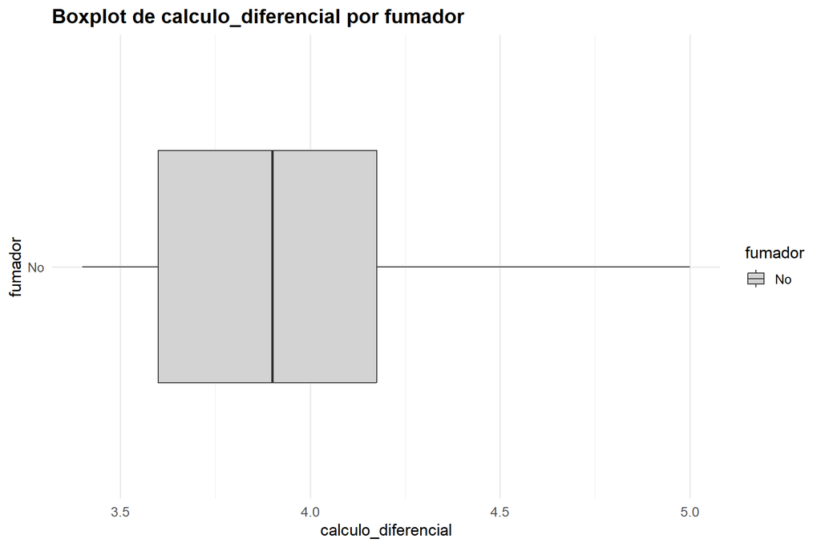

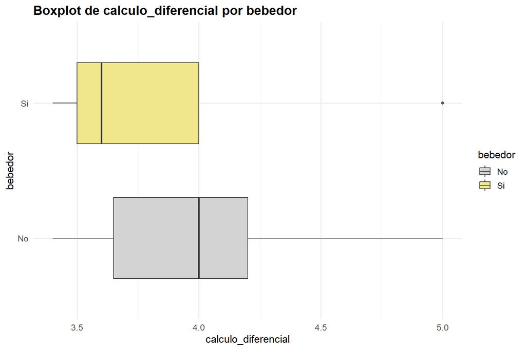

[6 more figures not shown]

```r
for (nv in num_vars) {
    for (gvar in cat_vars) {
        g_fac <- droplevels(as.factor(data[[gvar]]))
        print(boxplot_grouped(values = data[[nv]], groups = g_fac, nv = nv, gvar = gvar))
    }
}
```